# Ejercicios GLMs y Multivariante

## Ejercicio: GLM y multivariante

Estudio sobre el efecto del uso de suelo sobre los polinizadores. En 38 puntos utlizando círculos concéntricos de radio 100, 250, 500 y 750 m, se midieron diferentes coberturas y usos de suelo y, posteriormente, se estimaron el número de polinizadores. Se midieron 8 coberturas distntas: área urbanizada (Prop_imp), hábitats ricos en fores (Prop_fow), infraestructuras doméstcas (incluyendo parques) (Prop_domestcinfrastructure), jardines (Prop_gard), áreas con cobertura arbolada (Prop_tree), suelo agrícola (Prop_ag), áreas abiertas (Prop_open) y carreteras (Prop_road).

Se quiere construir un modelo que nos permita investgar la relación entre el número de polinizadores (peak_colony) y las diferentes coberturas del suelo medidas en un radio de 750 m.

#### Objetvos:

1. Reducir la dimensionalidad de las variables de cobertura del suelo y sintetzar toda esta variabilidad en unas pocas variables (máximo 2).
2. Generar un modelo estadístco que permita explicar el número de polinizadores en función de las característcas del paisaje en términos de tpo de coberturas y usos del suelo.

### Cargar los datos

```r
poli <- read.table("polinizacion.txt",header=T)
head(poli)
```

```
  Site peak_colony Prop_imp100 Prop_flow100 Prop_domesticinfrastructure100
1   MY        2822   0.0000000   0.59318521                      0.0000000
2   AD           4   0.4304040   0.32636402                      0.8525614
3   AI           1   0.1442782   0.00000000                      0.1965636
4   AN           1   0.7187448   0.21098314                      0.9297279
5   BA           1   0.6546491   0.25044018                      0.8847154
6   BL           1   0.7393377   0.07451079                      0.8464626
  Prop_open100 Prop_tree100 Prop_ag100 Prop_gard100 Prop_road100 Prop_imp250
1    0.5931852   0.40681479  0.5931852   0.00000000  0.000165810  0.00000000
2    0.6547272   0.14743857  0.0000000   0.32636402  0.001915868  0.43888785
3    0.1593226   0.80343637  0.0000000   0.00000000  0.001150937  0.08004157
4    0.4455016   0.07027208  0.0000000   0.21098314  0.001001502  0.67856757
5    0.4621447   0.11528465  0.0000000   0.23006624  0.001006121  0.66598245
6    0.5150527   0.15353738  0.0000000   0.06154875  0.002007025  0.65843379
  Prop_flow250 Prop_domesticinfrastructure250 Prop_open250 Prop_tree250
```

[output cut: 41 more lines]

### Análisis exploratorios

```r
library(corrgram)
corrgram(poli[,27:34], lower.panel = panel.pts,upper.panel = panel.conf, diag.panel = panel.density)
```

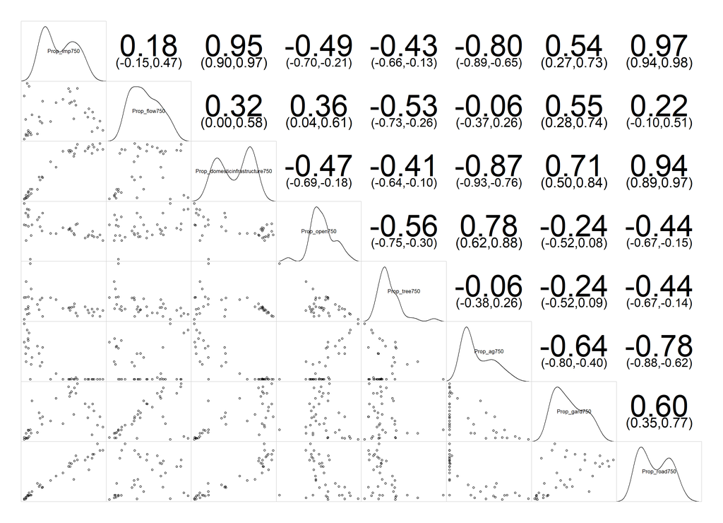

### Hacer PCA

```r
pca_poli <- prcomp(poli[,-c(1:26)], scale = T)
summary(pca_poli)
```

```
Importance of components:
                          PC1    PC2    PC3     PC4     PC5     PC6     PC7
Standard deviation     2.1535 1.4667 0.9199 0.48302 0.28118 0.19286 0.11714
Proportion of Variance 0.5797 0.2689 0.1058 0.02916 0.00988 0.00465 0.00172
Cumulative Proportion  0.5797 0.8486 0.9544 0.98356 0.99344 0.99809 0.99981
                           PC8
Standard deviation     0.03921
Proportion of Variance 0.00019
Cumulative Proportion  1.00000
```

```r
pca_poli$rotation[,1:2]
```

```
                                      PC1           PC2
Prop_imp750                     0.4400965 -0.0004399965
Prop_flow750                    0.1471257  0.5120752931
Prop_domesticinfrastructure750  0.4584106  0.0367988149
Prop_open750                   -0.2469484  0.5604824442
Prop_tree750                   -0.1559495 -0.5784133168
Prop_ag750                     -0.4154653  0.2582367962
Prop_gard750                    0.3494334  0.1415030037
Prop_road750                    0.4410328  0.0318224679
```

#### Interpretar matriz factorial y correlacionar variables originales con PCA

```r
library(factoextra)
fviz_pca_var(pca_poli)
```

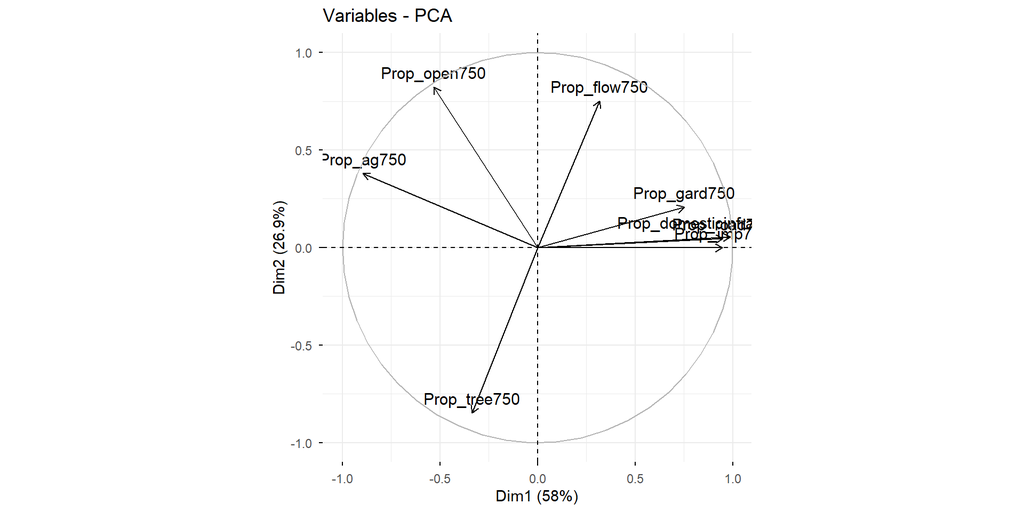

#### Añadir los dos primeros ejes a los datos

```r
poli$pca1<-pca_poli$x[,1]
poli$pca2<-pca_poli$x[,2]
```

#### Hacer modelo

```r
glm_poli1<-glm(peak_colony~pca1+pca2,poli,family = "poisson")
library(car)
Anova(glm_poli1, type = "III")
```

```
Analysis of Deviance Table (Type III tests)

Response: peak_colony
     LR Chisq Df Pr(>Chisq)
pca1   5221.8  1  < 2.2e-16 ***
pca2   9531.8  1  < 2.2e-16 ***
---
Signif. codes:  0 '***' 0.001 '**' 0.01 '*' 0.05 '.' 0.1 ' ' 1
```

#### Analizar supuestos del modelo

```r
par(mfcol=c(2,2))
plot(glm_poli1)
```

```r
library(aods3)
gof(glm_poli1)
```

```
D  = 999.9372, df = 35, P(>D) = 3.025866e-187
X2 = 1125.487, df = 35, P(>X2) = 1.158689e-213
```

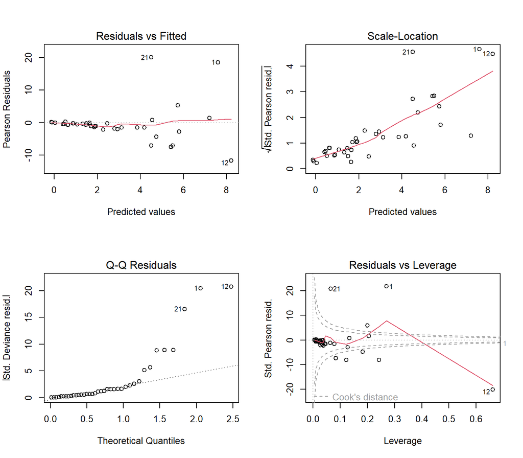

#### Modelo binomial negativo

```r
library(MASS)
glm_poli2 <- glm.nb(peak_colony ~ pca1 + pca2, poli)
Anova(glm_poli2, type="III")
```

```
Analysis of Deviance Table (Type III tests)

Response: peak_colony
     LR Chisq Df Pr(>Chisq)
pca1   443.61  1  < 2.2e-16 ***
pca2   166.06  1  < 2.2e-16 ***
---
Signif. codes:  0 '***' 0.001 '**' 0.01 '*' 0.05 '.' 0.1 ' ' 1
```

#### Supuestos del modelo

```r
par(mfcol=c(2,2))
plot(glm_poli2)
```

```r
gof(glm_poli2)
```

```
D  = 26.2212, df = 35, P(>D) = 0.8579195
X2 = 37.4745, df = 35, P(>X2) = 0.3562873
```

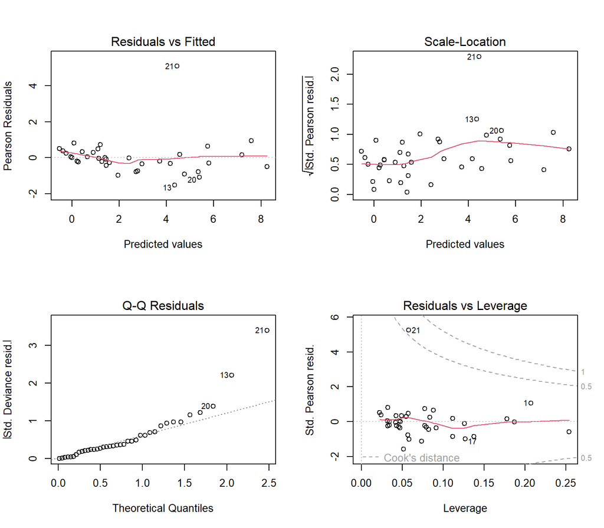

#### Interpretación del modelo

```r
summary(glm_poli2)
```

```
Call:
glm.nb(formula = peak_colony ~ pca1 + pca2, data = poli, init.theta = 4.995065004,
    link = log)

Coefficients:
            Estimate Std. Error z value Pr(>|z|)
(Intercept)  2.53568    0.11051   22.95   <2e-16 ***
pca1        -0.97994    0.04951  -19.79   <2e-16 ***
pca2         0.83538    0.06621   12.62   <2e-16 ***
---
Signif. codes:  0 '***' 0.001 '**' 0.01 '*' 0.05 '.' 0.1 ' ' 1

(Dispersion parameter for Negative Binomial(4.9951) family taken to be 1)

    Null deviance: 953.975  on 37  degrees of freedom
Residual deviance:  26.221  on 35  degrees of freedom
AIC: 263.82

Number of Fisher Scoring iterations: 1

              Theta:  5.00
          Std. Err.:  1.41

 2 x log-likelihood:  -255.823
```

```r
library(visreg)
par(mfcol=c(2,2))
visreg(glm_poli2, scale="response")
```

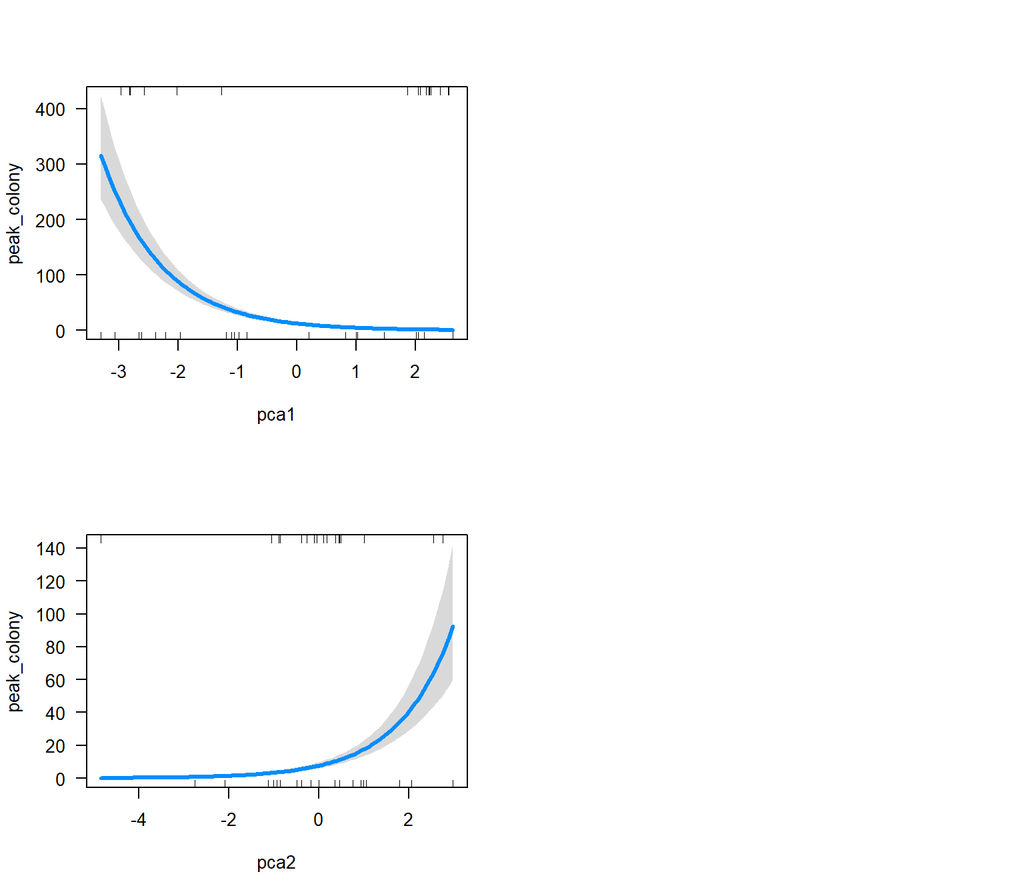